# BR PS 3

AP

9/30/2021

## Exercise 3.1

### Part A

To get to the model below, I assumed that the mode was .4; then, I ran simulations for Beta(5,7), which was too broad, then Beta(9,13), which was too narrow, then found a happy medium with Beta(7,10). I assumed that my friend was 90% confident about their chances being between 20% and 60%.

```r
simparta <- rbeta(10000,7,10)
quantile(simparta, c(.05,.5,.95))
```

```
##        5%       50%       95%
## 0.2277484 0.4078553 0.6085071
```

```r
summarize_beta(7,10)
```

```
##        mean mode        var        sd
## 1 0.4117647  0.4 0.01345636 0.1160016
```

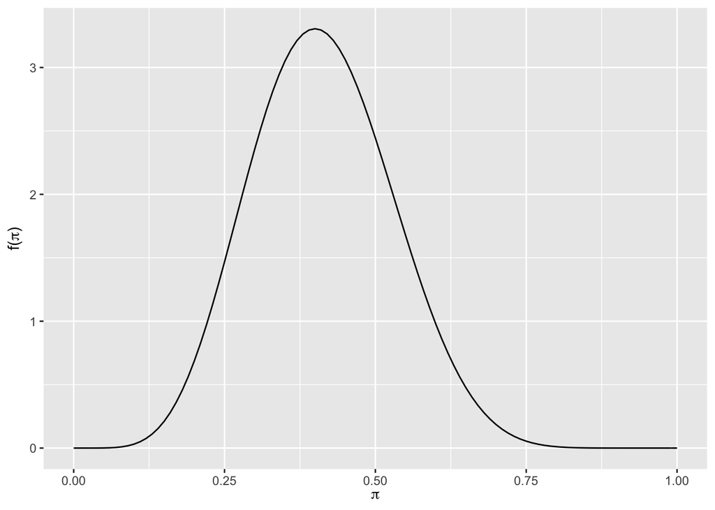

```r
plot_beta(7,10)
```

### Part B

I started by assuming I wanted the mode of my distribution to be .8. Beta(3, 1.5) had a variance that was slightly too low, and Beta(1.5, 1.125) had a variance that was slightly too high, so the happy medium was Beta(2,1.25).

```r
summarize_beta(2,1.25)
```

```
##        mean mode        var        sd
## 1 0.6153846  0.8 0.05569092 0.2359892
```

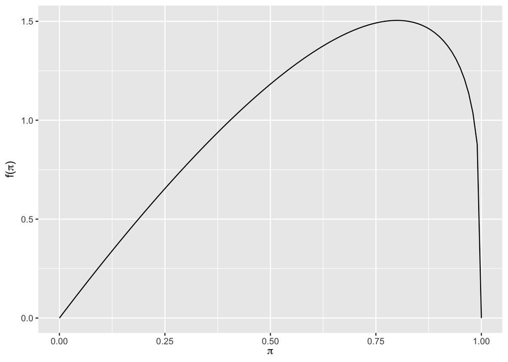

```r
plot_beta(2, 1.25)
```

### Part C

For this question, I assumed that the mode of the distribution was at .9 and then guessed and checked simulations for several beta distributions. I settled on Beta(118,14) because the mode and the lower end of the confidence interval were approximately where I wanted them to be, although the high end of the confidence interval remained too low - although my aunt was probably bragging when she said the probability could be 100%, anyway.

```r
simpartc <- rbeta(10000,118,14)
quantile(simpartc, c(.025,.5,.975))
```

```
##      2.5%       50%     97.5%
## 0.8369402 0.8959095 0.9389727
```

```r
summarize_beta(118,14)
```

```
##        mean mode          var         sd
## 1 0.8939394  0.9 0.0007128703 0.02669963
```

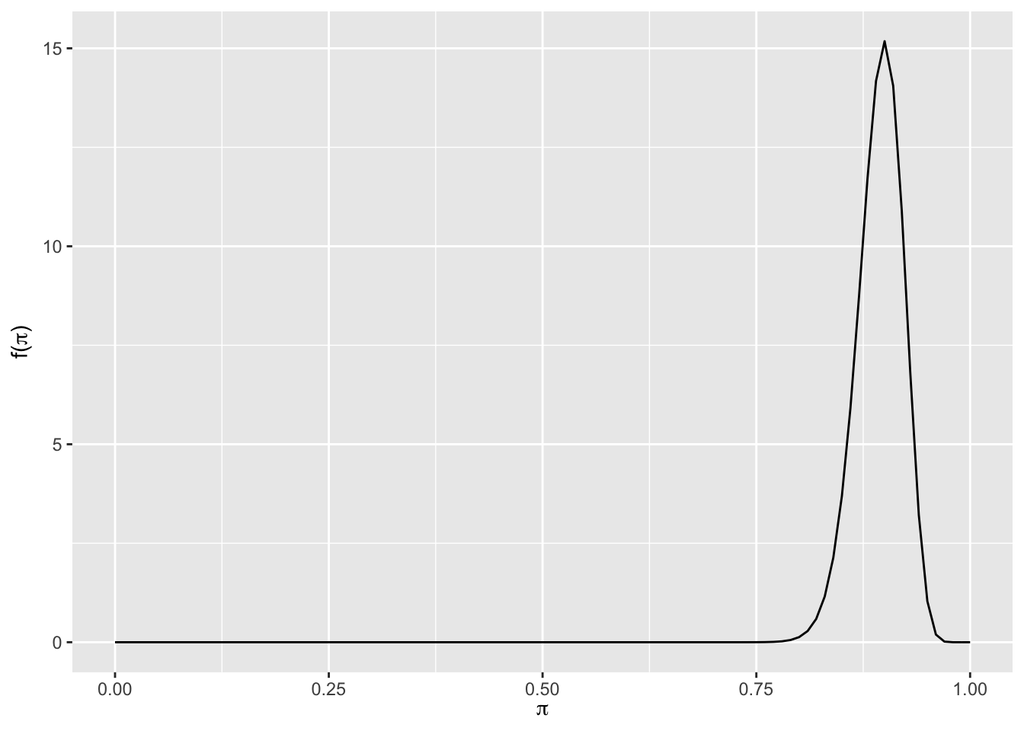

```r
plot_beta(118,14)
```

### Part D

Even though my friend would probably say their chances are reflected by Beta(1,1) (a straight horizontal line), I would say that it’s probably not too close to either of the extremes (they probably, in reality, won’t burn their resume OR hire them on the spot). Beta(3,3) seemed to me to have the right amount of spread that it remains true to my friend’s uncertainty while also reflecting reality.

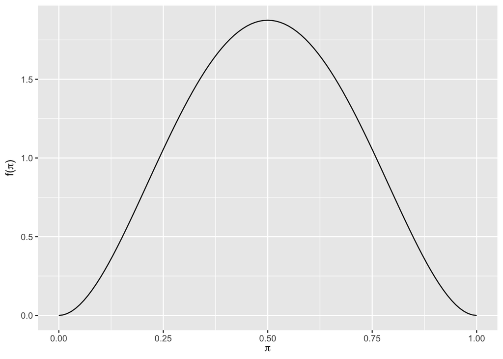

```r
plot_beta(3,3)
```

## Exercise 3.2

### Part A

I first assumed that the mode of my distribution would be .8. I tried Beta(9,3), which was much too broad, and Beta(81,21), which was too narrow; then I settled on Beta(41,11), which was the happy medium.

```r
sim32a <- rbeta(10000,41,11)
quantile(sim32a, c(.05,.5,.95))
```

```
##        5%       50%       95%
## 0.6900800 0.7923285 0.8742478
```

```r
summarize_beta(41,11)
```

```
##        mean mode        var         sd
## 1 0.7884615  0.8 0.00314698 0.05609795
```

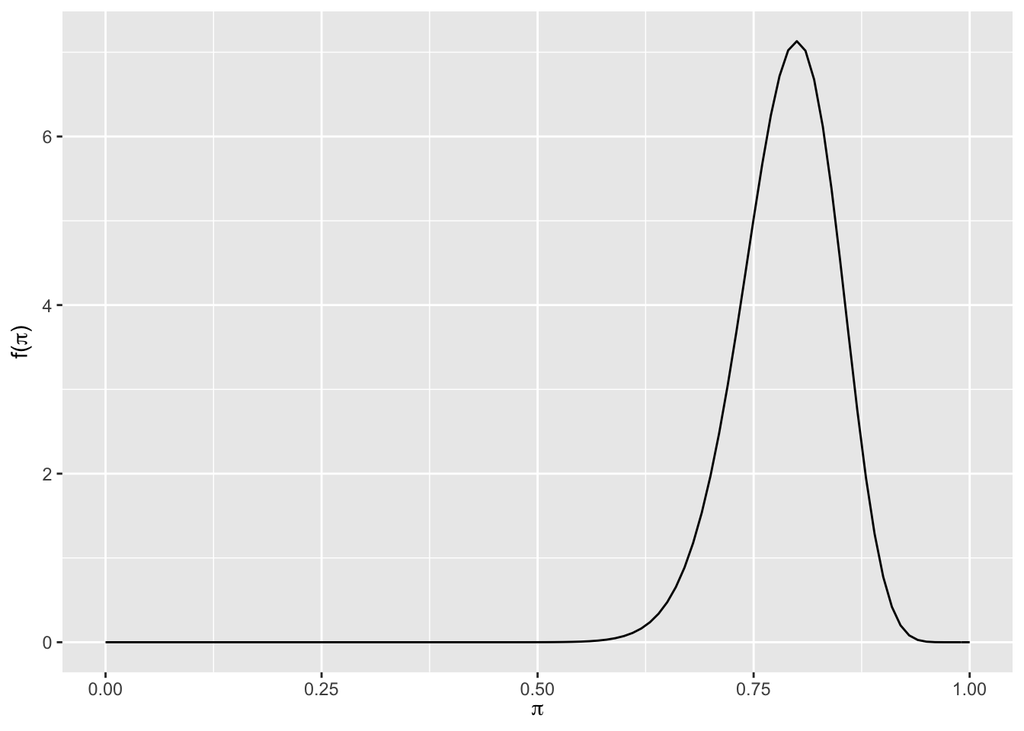

```r
plot_beta(41,11)
```

### Part B

For this problem I used the same guess and check method as before, assuming the mode was .9. I continued until I found a combination whose variance was .08.

```r
summarize_beta(1.1, (1+(.1/9)))
```

```
##        mean mode        var       sd
## 1 0.5210526  0.9 0.08021468 0.283222
```

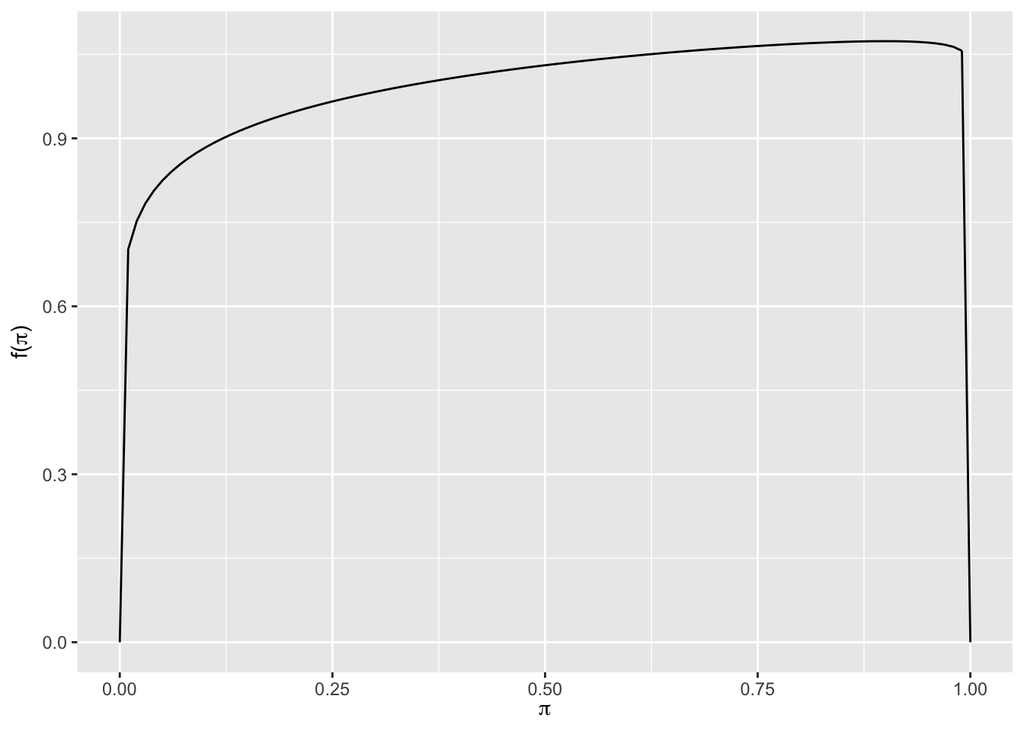

```r
plot_beta(1.1, (1+(.1/9)))
```

### Part C

I started with the assumption that the mode of my distribution was .85, and continued plugging and chugging possibilities until the 90% confidence level reflected my friend’s estimation of 75-95%. It wasn’t perfect, but it was the closest I could get. The final distribution was Beta(35,7)

```r
sim32c <- rbeta(100000, 35, 7)
quantile(sim32c, c(.05, .5, .95))
```

```
##        5%       50%       95%
## 0.7315434 0.8384218 0.9165969
```

```r
summarize_beta(35,7)
```

```
##        mean mode         var         sd
## 1 0.8333333 0.85 0.003229974 0.05683286
```

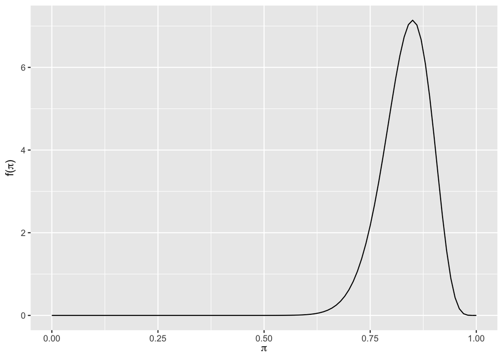

```r
plot_beta(35,7)
```

### Part D

I wanted my beta distribution for this question to reflect my friend’s lack of knowledge by being very broad. I also wanted it to reflect MY intuition on the subject, which is that there probably is at least SOME chance that they’ve run out, so I wouldn’t want the distribution to be too heavy on low values. I checked several distributions and Beta(2.5, 4.5) fit my needs the best.

```r
sim32d <- rbeta(100000, 2.5, 4.5)
quantile(sim32d, c(.05, .5, .95))
```

```
##        5%       50%       95%
## 0.1040064 0.3421345 0.6583328
```

```r
summarize_beta(2.5,4.5)
```

```
##        mean mode        var        sd
## 1 0.3571429  0.3 0.02869898 0.1694077
```

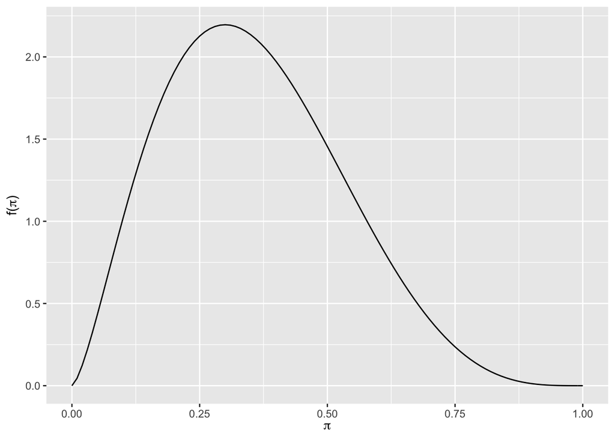

```r
plot_beta(2.5,4.5)
```

## Exercise 3.3

### Part A

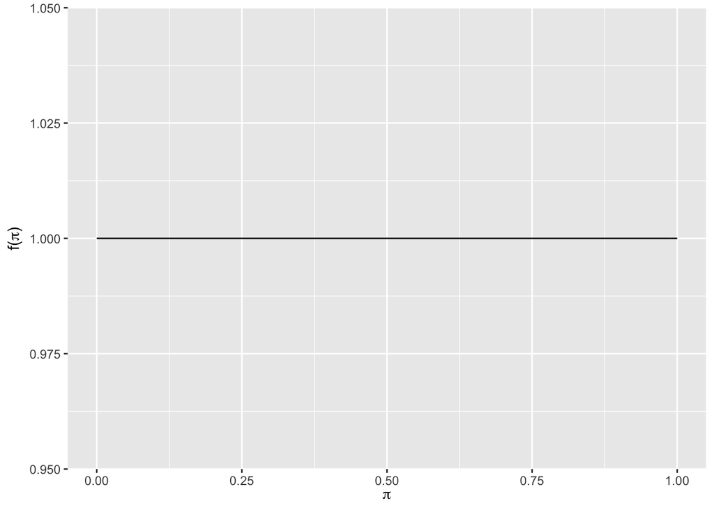

```r
plot_beta(1,1)
```

### Part B

```r
summarize_beta(1,1)
```

```
##   mean mode        var        sd
## 1  0.5  NaN 0.08333333 0.2886751
```

The mean of beta(1,1) is .5, which makes sense because it’s exactly in the middle of the possible values; we have no information to move us either way, so we assume that we’re just as likely to have a success as a failure.

### Part C

```r
summarize_beta(1,1)
```

```
##   mean mode        var        sd
## 1  0.5  NaN 0.08333333 0.2886751
```

The standard deviation is .29.

### Part D

```r
summarize_beta(2,2)
```

```
##   mean mode  var        sd
## 1  0.5  0.5 0.05 0.2236068
```

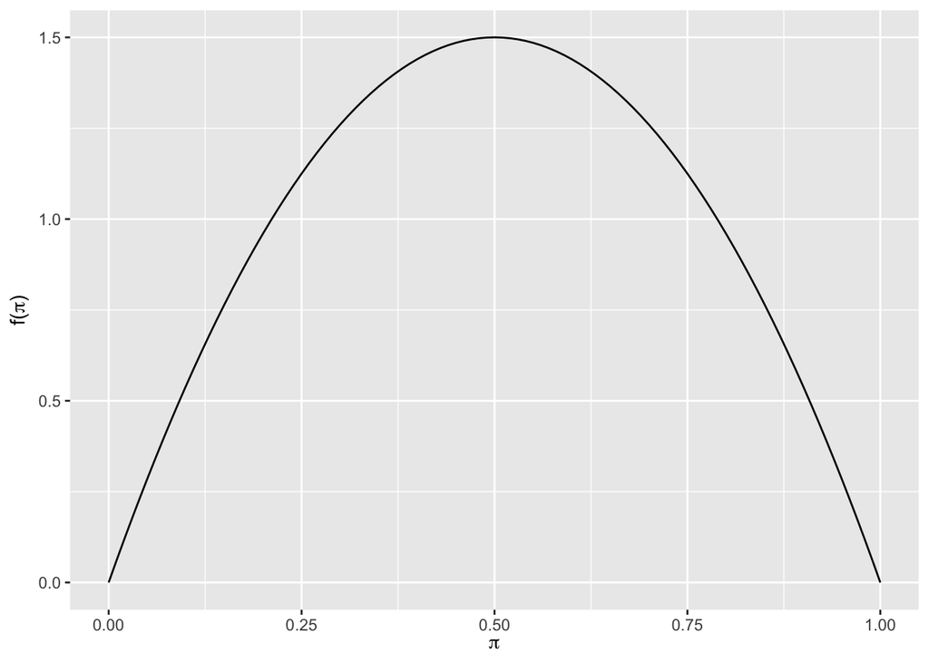

```r
plot_beta(2,2)
```

### Part E

```r
summarize_beta(.5,.5)
```

```
##   mean    mode   var        sd
## 1  0.5 0 and 1 0.125 0.3535534
```

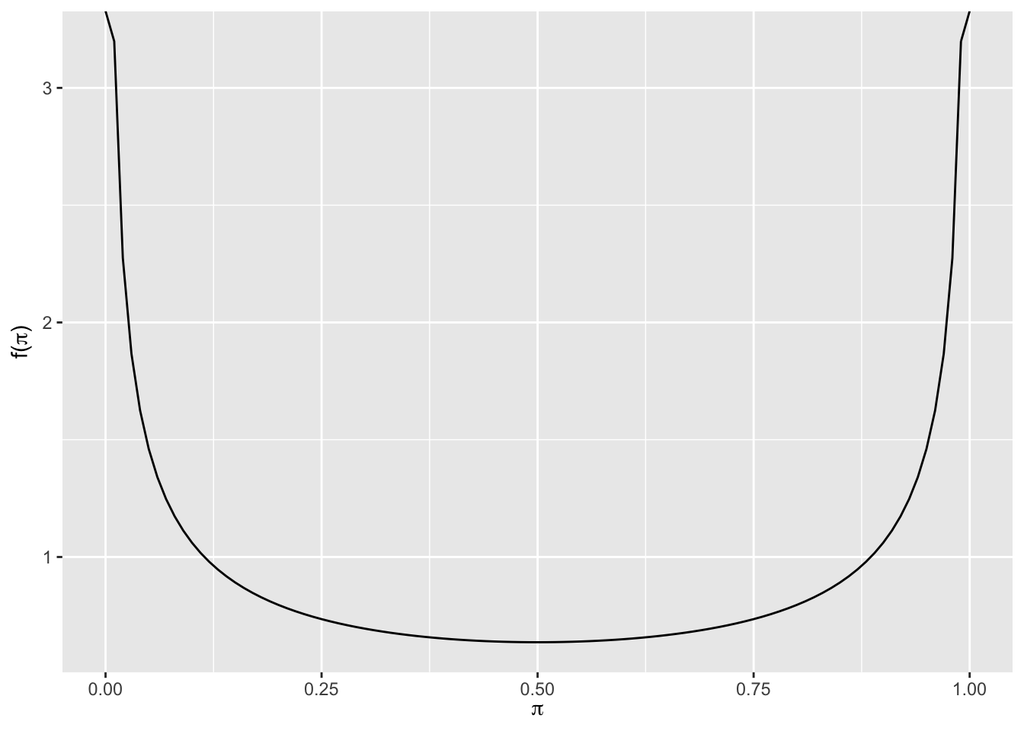

```r
plot_beta(.5,.5)
```

## Exercise 3.4

### Part A

Beta(.5,.5)

### Part B

Beta(2,2)

### Part C

Beta(6,2)

### Part D

Beta(1,1)

### Part E

Beta(.5,6)

### Part F

Beta(6,6)

## Exercise 3.5

### Part A

Beta(1,.3)

### Part B

Beta(3,3)

### Part C

Beta(4,2)

### Part D

Beta(2,1)

### Part E

Beta(5,6)

### Part F

Beta(6,3)

## Exercise 3.6

First I’ll set up some mean, mode, and standard deviation functions to do the “calculating” for me.

```r
meanbeta <- function(alpha, beta) {
  alpha/(alpha+beta)
}

modebeta <- function(alpha,beta) {
  (alpha - 1)/(alpha + beta - 2)
}

sdbeta <- function(alpha,beta) {
  sqrt((alpha*beta)/(((alpha + beta)^2)*(alpha + beta + 1)))
}
```

### Part A

We can think of the mean visually as the “balancing point” of the distribution. A, B, D, and F all have means of .5. E has a *lower* mean than .5, since it’s more concentrated on the left side. That means it has the lowest mean. C has a *higher* mean than .5, because it’s more concentrated on the right side. That means it has the highest mean.

```r
meanbeta(.5,6)
```

```
## [1] 0.07692308
```

```r
meanbeta(6,2)
```

```
## [1] 0.75
```

E’s mean is .077, and C’s mean is .75.

### Part B

The mode of a beta distribution, visually, is the x-axis location of the highest point on the graph of the f($\pi$) function. E has the lowest mode, because its highest point occurs at/near 0. C has the highest mode, because its highest point occurs the farthest right. (I didn’t count A, since it is bimodal, but technically it has the lowest AND highest means (0 and 1).)

```r
## modebeta() won't work for E because alpha and beta are below 1, so I just used common sense to figure this one out.
modebeta(6,2)
```

```
## [1] 0.8333333
```

E’s mode is 0, and C’s is .83.

### Part C

The one with the smallest standard deviation is basically the one that is spread out the least, which in this set is E. The one with the highest standard deviation is one that is spread out the most, which in this set would be A.

```r
sdbeta(.5,6)
```

```
## [1] 0.09730085
```

```r
sdbeta(.5,.5)
```

```
## [1] 0.3535534
```

E’s standard deviation is .097. A’s is .354.

## Exercise 3.7

### Part A

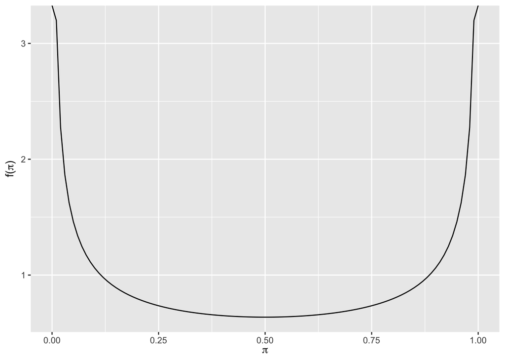

```r
## Graph A
plot_beta(.5,.5)
```

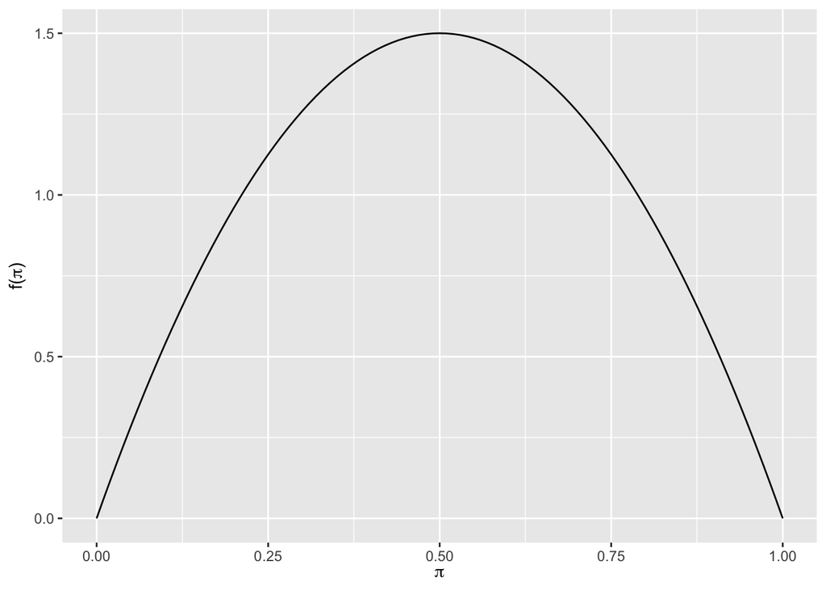

```r
## Graph B
plot_beta(2,2)
```

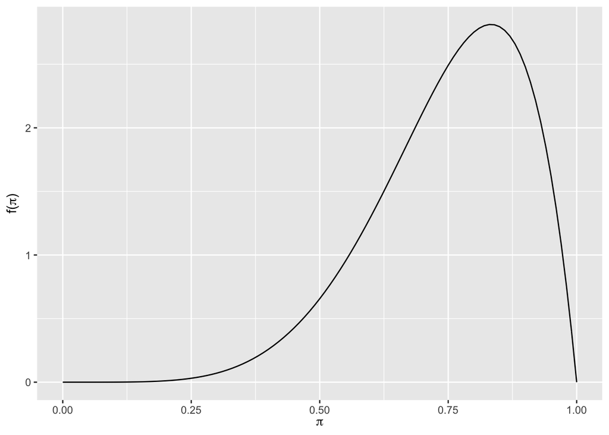

```r
## Graph C
plot_beta(6,2)
```

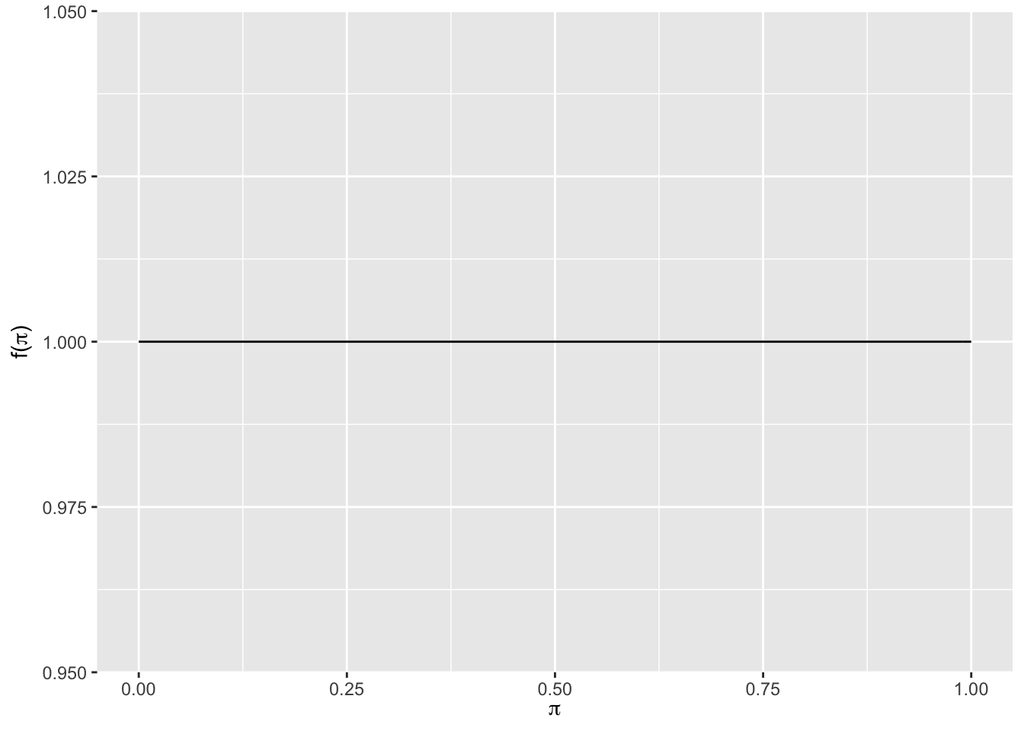

```r
## Graph D
plot_beta(1,1)
```

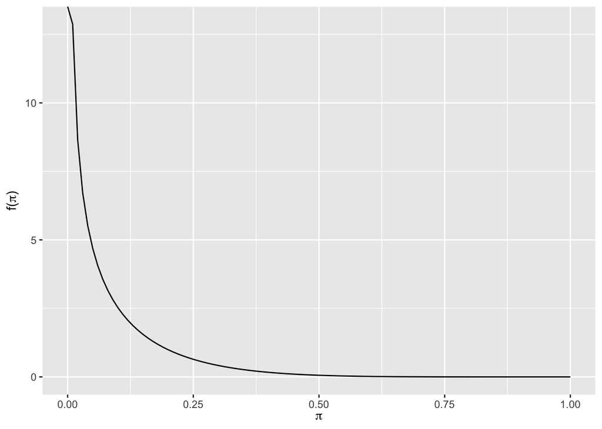

```r
## Graph E
plot_beta(.5, 6)
```

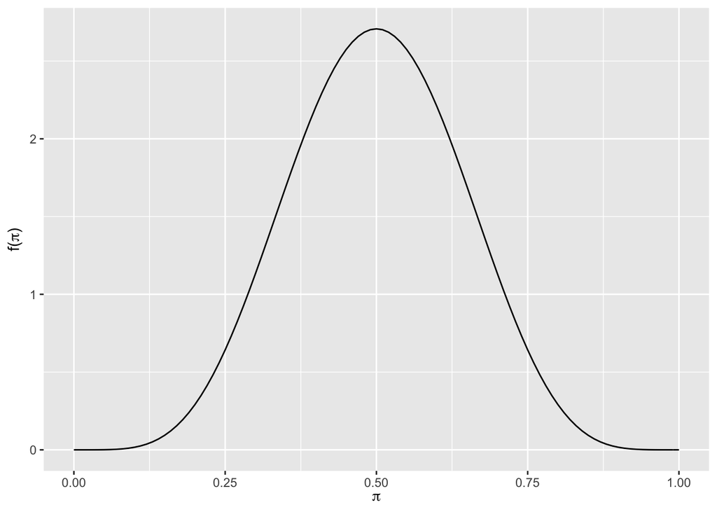

```r
## Graph F
plot_beta(6,6)
```

### Part B

```r
## Done in order, so result set 1 is graph A, result set 2 is graph B, etc.
alpha <- c(.5, 2, 6, 1, .5, 6)
beta <- c(.5, 2, 2, 1, 6, 6)

mapply(summarize_beta, alpha, beta)
```

```
##      [,1]      [,2]      [,3]       [,4]       [,5]        [,6]
## mean 0.5       0.5       0.75       0.5        0.07692308  0.5
## mode "0 and 1" 0.5       0.8333333  NaN        0           0.5
## var  0.125     0.05      0.02083333 0.08333333 0.009467456 0.01923077
## sd   0.3535534 0.2236068 0.1443376  0.2886751  0.09730085  0.138675
```

## Exercise 3.8

No thank you!

## Exercise 3.9

### Part A

Using my functions that I made, we’ll start with the North Dakotan:

```r
meanbeta(8,2)
```

```
## [1] 0.8
```

```r
modebeta(8,2)
```

```
## [1] 0.875
```

```r
sdbeta(8,2)
```

```
## [1] 0.1206045
```

And now the Lousianan:

```r
meanbeta(1,20)
```

```
## [1] 0.04761905
```

```r
modebeta(1,20)
```

```
## [1] 0
```

```r
sdbeta(1,20)
```

```
## [1] 0.04540298
```

### Part B

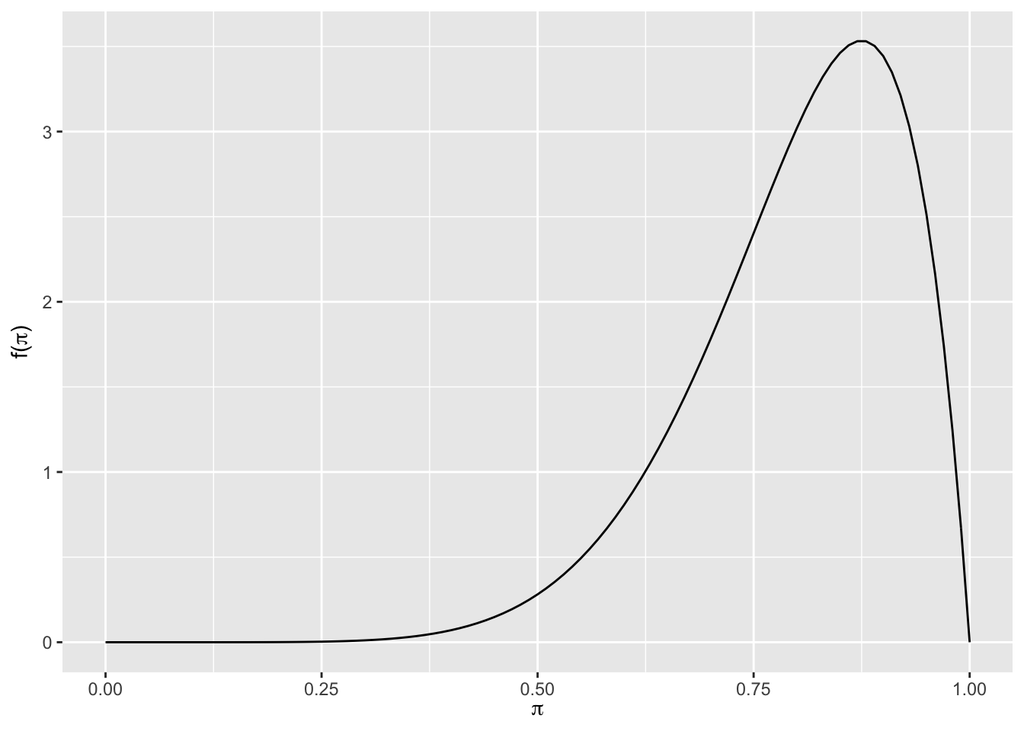

```r
## ND
plot_beta(8,2)
```

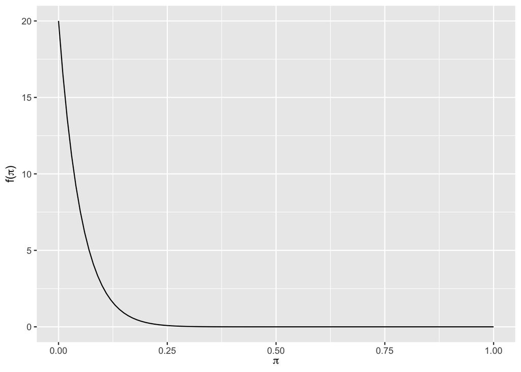

```r
## LA
plot_beta(1,20)
```

### Part C

The North Dakotan, compared to the Louisianan, thinks that a higher proportion of Americans say “pop,” and in fact thinks that the proportion is probably around 80%. However, the Louisianan thinks that a very low proportion of Americans say “pop,” and is much more sure about his prior estimate than the North Dakotan.

## Exercise 3.10

### Part A

We’ll start with North Dakota:

```r
summarize_beta_binomial(8, 2, 12, 50)
```

```
##       model alpha beta      mean      mode         var         sd
## 1     prior     8    2 0.8000000 0.8750000 0.014545455 0.12060454
## 2 posterior    20   40 0.3333333 0.3275862 0.003642987 0.06035716
```

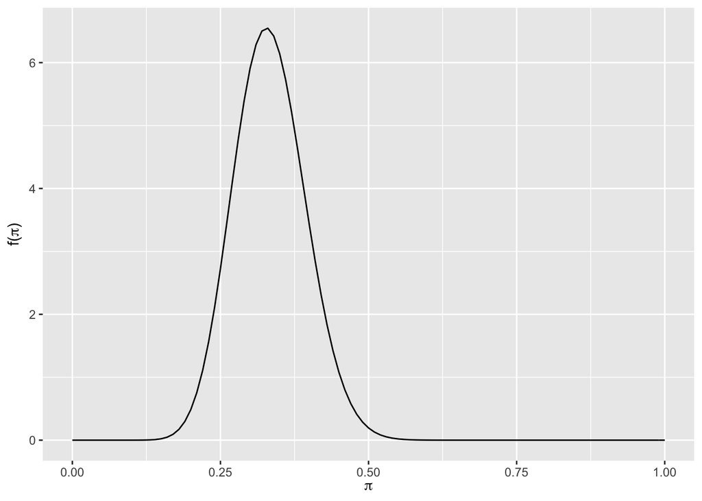

```r
plot_beta(20,40)
```

North Dakota’s posterior model can be represented by Beta(20,40).

Now we’ll do Louisiana:

```r
summarize_beta_binomial(1,20,12,50)
```

```
##       model alpha beta       mean     mode         var         sd
## 1     prior     1   20 0.04761905 0.000000 0.002061431 0.04540298
## 2 posterior    13   58 0.18309859 0.173913 0.002077410 0.04557861
```

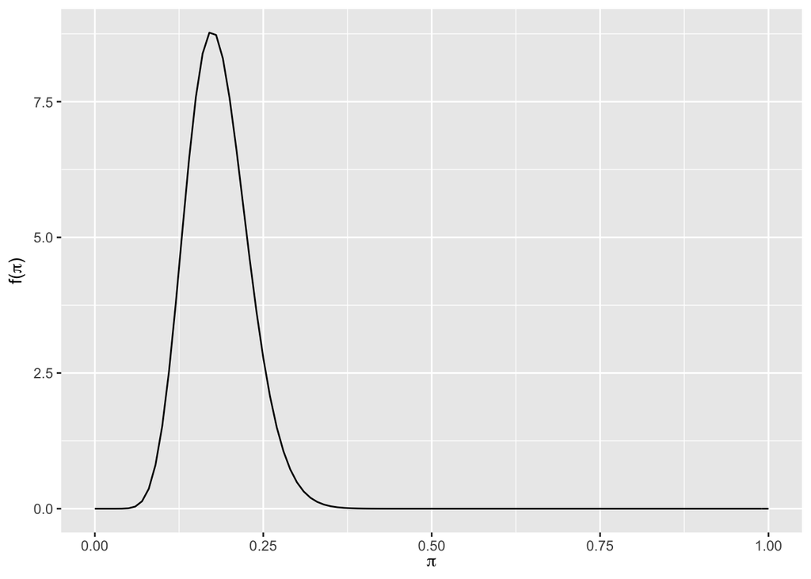

```r
plot_beta(13,58)
```

### Part B

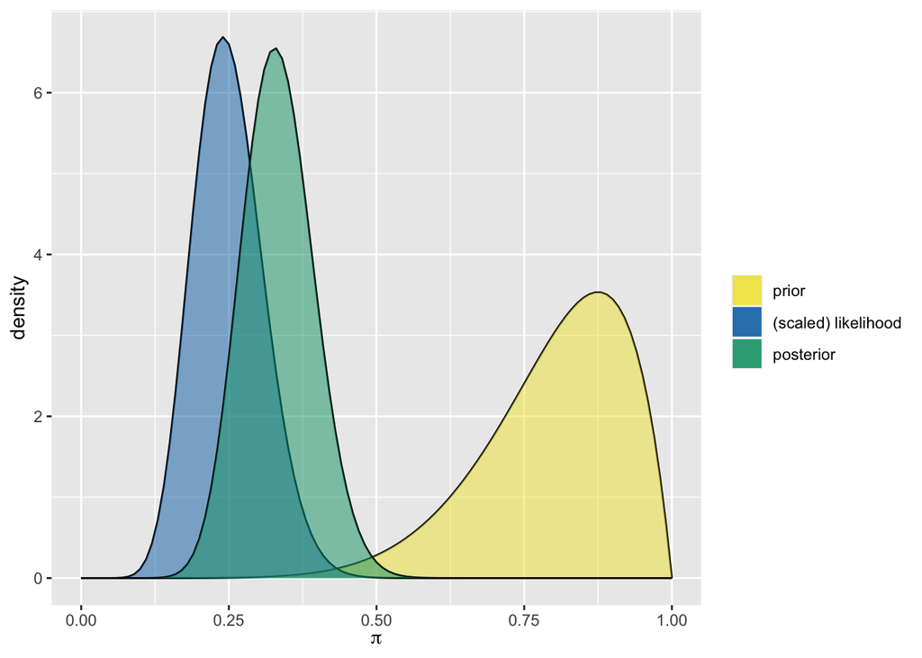

```r
plot_beta_binomial(8,2,12,50)
```

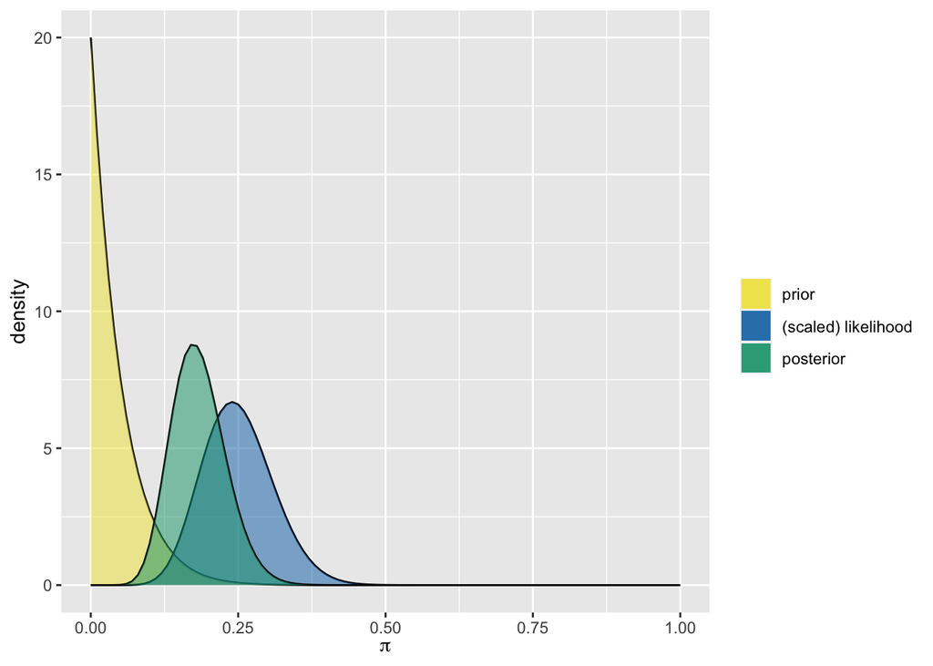

```r
plot_beta_binomial(1,20,12,50)
```

## Exercise 3.11

### Part A

Since the mean is .25, we know that (alpha)/(alpha+beta) = .25, which also means that beta is 3 times alpha. Since the mode is 5/22, alpha must be 6 and beta must be 18, because (6-1)/(6+18-2) = 5/22 and $ 6*3 = 18 $. Plotting Beta(6,18)…

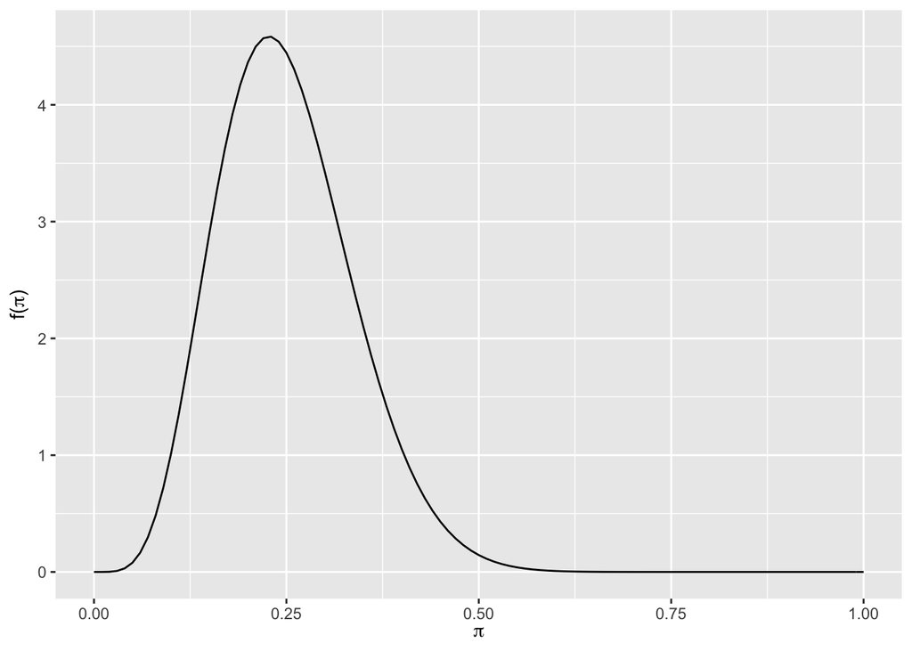

```r
plot_beta(6,18)
```

### Part B

Using plot_beta_binomial() and summarize_beta_binomial() to specify the posterior…

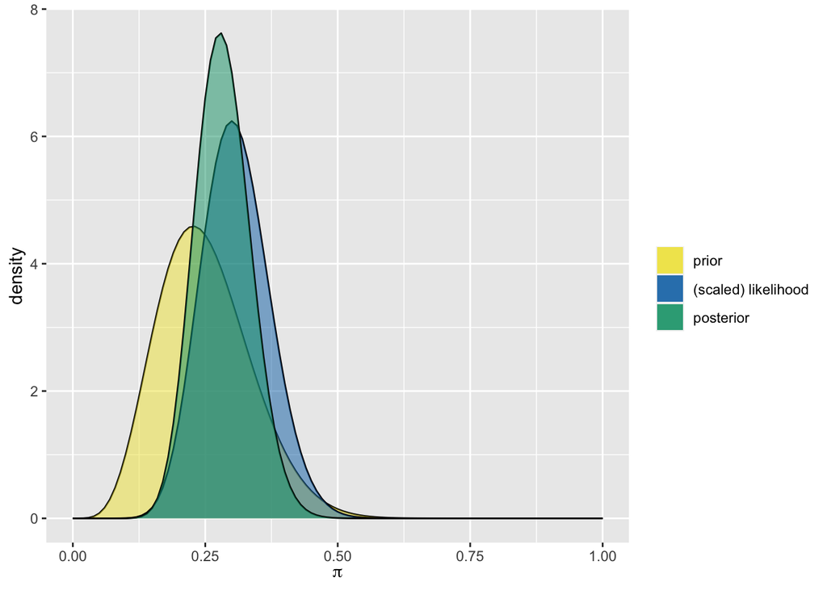

```r
plot_beta_binomial(6, 18, y=15, n=50)
```

```r
summarize_beta_binomial(6, 18, y=15, n=50)
```

```
##       model alpha beta      mean      mode         var         sd
## 1     prior     6   18 0.2500000 0.2272727 0.007500000 0.08660254
## 2 posterior    21   53 0.2837838 0.2777778 0.002710007 0.05205773
```

The posterior model for $\pi$ is Beta(21,53).

### Part C

```r
summarize_beta_binomial(6, 18, y=15, n=50)
```

```
##       model alpha beta      mean      mode         var         sd
## 1     prior     6   18 0.2500000 0.2272727 0.007500000 0.08660254
## 2 posterior    21   53 0.2837838 0.2777778 0.002710007 0.05205773
```

The mean of the posterior is .284, the mode is .278, and the standard deviation is .052.

### Part D

I would say that the posterior more closely resembles the data than the prior, which makes sense because the prior model is equivalent to a survey of approx. 22 people, while the data is a survey of 50 people - you would expect a larger sample to sway our opinion more.

## Exercise 3.12

### Part A

I want the mode of my distribution to be .15, and the 95% confidence interval to roughly be in between .10 and .25. The prior that fits these conditions the best is Beta(13,69).

```r
sim312a <- rbeta(100000, 13, 69)
quantile(sim312a, c(.025, .5, .975))
```

```
##       2.5%        50%      97.5%
## 0.08823511 0.15591318 0.24502821
```

```r
summarize_beta(13,69)
```

```
##        mean mode         var         sd
## 1 0.1585366 0.15 0.001607262 0.04009067
```

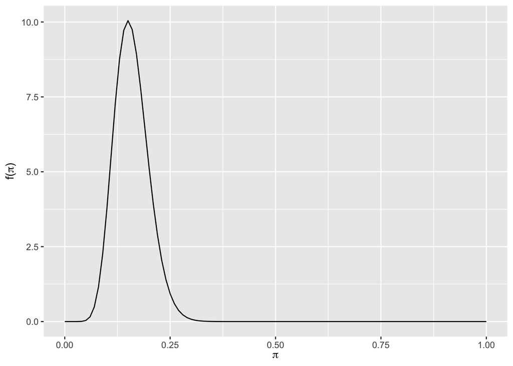

```r
plot_beta(13,69)
```

### Part B

```r
summarize_beta_binomial(13,69,y=30,n=90)
```

```
##       model alpha beta      mean      mode         var         sd
## 1     prior    13   69 0.1585366 0.1500000 0.001607262 0.04009067
## 2 posterior    43  129 0.2500000 0.2470588 0.001083815 0.03292135
```

The posterior model is Beta(43,129).

### Part C

```r
meanbeta(43,129)
```

```
## [1] 0.25
```

```r
modebeta(43,129)
```

```
## [1] 0.2470588
```

```r
sdbeta(43,129)
```

```
## [1] 0.03292135
```

### Part D

I would expect the posterior to be pretty evenly between the prior and the data, since the prior is essentially a sample size of 80 and the data is a sample size of 90 (so perhaps a bit closer to the data than the prior, but not much).

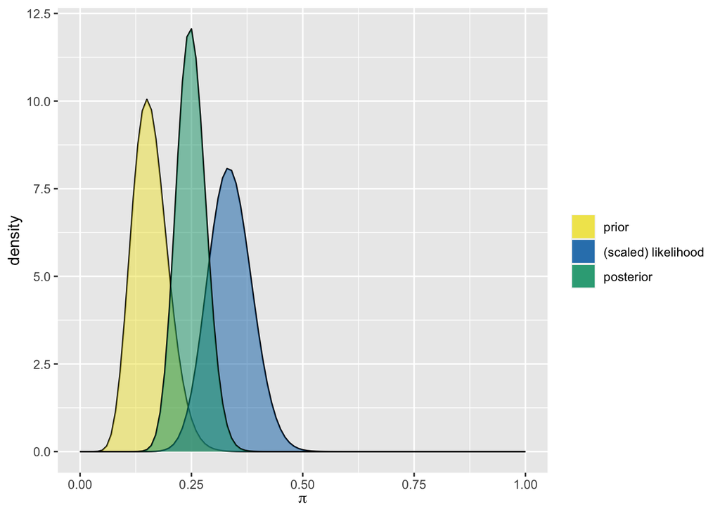

```r
plot_beta_binomial(13,69,y=30,n=90)
```

The graph above supports my thinking.

## Exercise 3.13

### Part A

I want my prior model to have a mode somewhere around .45-.50 and 95% of the data to be between .35 and .6. I guessed and checked several values of alpha and beta and came up with the prior model below…

```r
a <- 31
b <- 37
sim313a <- rbeta(100000, a, b)
quantile(sim313a, c(.025, .5, .975))
```

```
##      2.5%       50%     97.5%
## 0.3401448 0.4555038 0.5739268
```

```r
summarize_beta(a,b)
```

```
##        mean      mode        var         sd
## 1 0.4558824 0.4545455 0.00359498 0.05995815
```

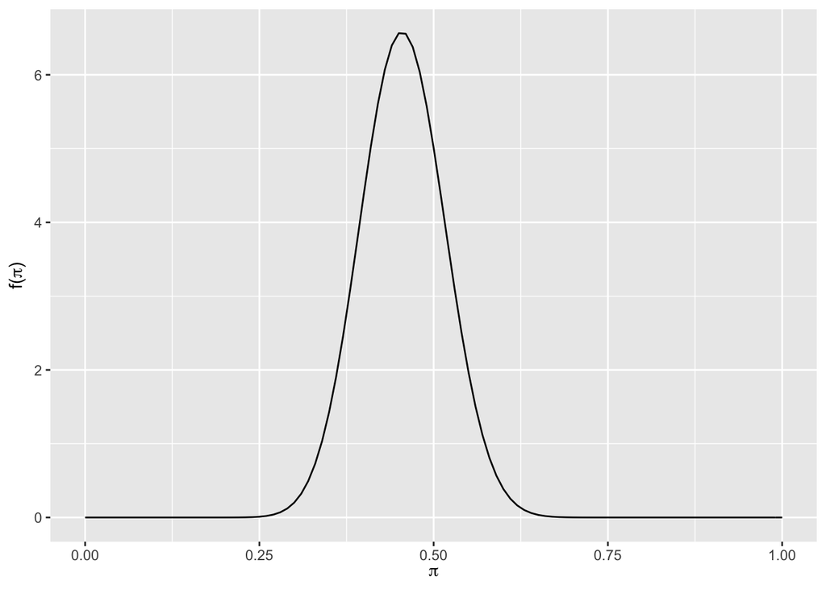

```r
plot_beta(a,b)
```

The prior model Beta(31,37) represents my friend’s ideas.

### Part B

```r
summarize_beta_binomial(31,37, y=80, n=200)
```

```
##       model alpha beta      mean      mode         var         sd
## 1     prior    31   37 0.4558824 0.4545455 0.003594980 0.05995815
## 2 posterior   111  157 0.4141791 0.4135338 0.000901988 0.03003312
```

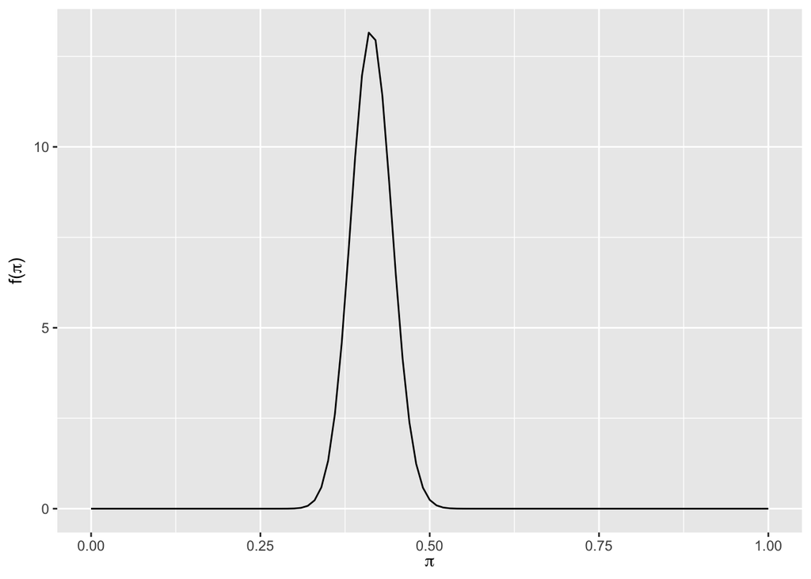

```r
plot_beta(111,157)
```

The posterior model is Beta(111,157).

### Part C

```r
meanbeta(111,157)
```

```
## [1] 0.4141791
```

```r
modebeta(111,157)
```

```
## [1] 0.4135338
```

```r
sdbeta(111,157)
```

```
## [1] 0.03003312
```

### Part D

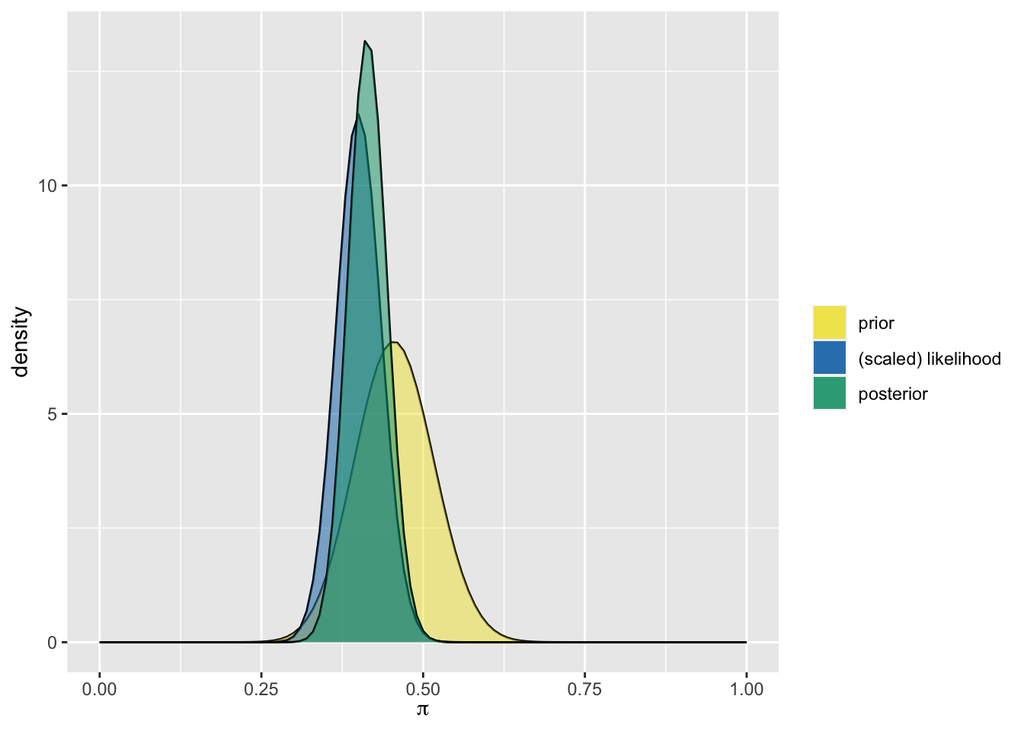

```r
plot_beta_binomial(31,37,80,200)
```

The posterior is narrower (more exact/confident) than the prior, and also more closely resembles the data than the prior (which makes sense because the prior approximated a sample size of 66 while the data had a sample size of 200).

## Exercise 3.14

I solved this and the next exercise using the following equations:
$$\alpha_1 + y = \alpha_2$$
$$\beta_1 + (n - y) = \beta_2$$

```r
summarize_beta_binomial(2,3,9,30)
```

```
##       model alpha beta      mean      mode         var         sd
## 1     prior     2    3 0.4000000 0.3333333 0.040000000 0.20000000
## 2 posterior    11   24 0.3142857 0.3030303 0.005986395 0.07737179
```

## Exercise 3.15

```r
summarize_beta_binomial(1,2,99,100)
```

```
##       model alpha beta      mean     mode          var         sd
## 1     prior     1    2 0.3333333 0.000000 0.0555555556 0.23570226
## 2 posterior   100    3 0.9708738 0.980198 0.0002719027 0.01648947
```

## Exercise 3.16

### Part A

The prior model’s mode is very close to 1, and it is very narrow, The scaled likelihood is centered around .2-ish, and is much more broad (less certain).

### Part B

The posterior is between the two, but more closely resembles the prior than the likelihood.

### Part C

I knew I wanted alpha to be much more than beta, but beta had to be greater than 1 since the prior model dipped back down before 1; I also knew the n had to be much lower than alpha + beta because the prior was more influential than the data in determining the posterior. With those pieces of information, as well as knowing that I wanted y/n to approximately equal .2 because that was the center of the data curve, I guessed and checked until I landed at the model below.

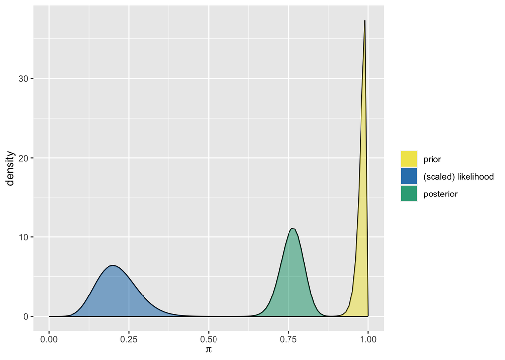

```r
plot_beta_binomial(100,2,8,40)
```

## Exercise 3.17

### Part A

The prior is extremely broad, and the center appears to be at .5. The likelihood function is much more narrow by comparison, and is centered around .1-ish.

### Part B

The posterior is much closer to the likelihood (data) than it is to the prior, and looks almost identical to the data.

### Part C

Here’s what I know: alpha and beta are approximately equal, probably 3,3 based on how broad the prior is and the slight concavity of the curve towards the ends (Beta(1,1) is a line; Beta(2,2) is a perfect slice of a circle). y/n is approximately .1, and n is many times larger than alpha + beta. Using that information and a little guess and check…

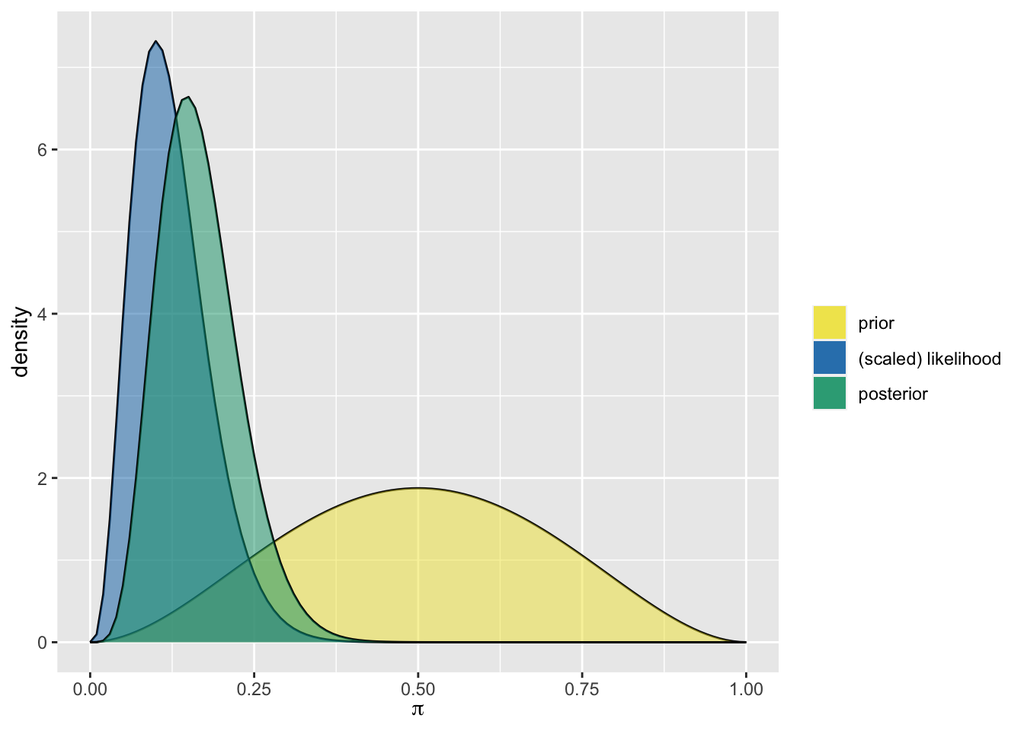

```r
plot_beta_binomial(3,3,3,30)
```